# Climate Change Impact on Agriculture Visual - Revised

Gabrielle Carbonel

2024-10-27

## Data

```r
climate_data <- read_csv("climate_change_impact_on_agriculture_2024.csv")
summary(climate_data)
```

```
##       Year        Country             Region           Crop_Type
##  Min.   :1990   Length:10000       Length:10000       Length:10000
##  1st Qu.:1999   Class :character   Class :character   Class :character
##  Median :2007   Mode  :character   Mode  :character   Mode  :character
##  Mean   :2007
##  3rd Qu.:2016
##  Max.   :2024
##  Average_Temperature_C Total_Precipitation_mm CO2_Emissions_MT
##  Min.   :-4.99         Min.   : 200.2         Min.   : 0.50
##  1st Qu.: 5.43         1st Qu.: 925.7         1st Qu.: 7.76
##  Median :15.18         Median :1611.2         Median :15.20
##  Mean   :15.24         Mean   :1611.7         Mean   :15.25
##  3rd Qu.:25.34         3rd Qu.:2307.0         3rd Qu.:22.82
##  Max.   :35.00         Max.   :2999.7         Max.   :30.00
##  Crop_Yield_MT_per_HA Extreme_Weather_Events Irrigation_Access_%
##  Min.   :0.450        Min.   : 0.000         Min.   :10.01
##  1st Qu.:1.449        1st Qu.: 2.000         1st Qu.:32.68
##  Median :2.170        Median : 5.000         Median :55.17
##  Mean   :2.240        Mean   : 4.981         Mean   :55.25
##  3rd Qu.:2.930        3rd Qu.: 8.000         3rd Qu.:77.58
##  Max.   :5.000        Max.   :10.000         Max.   :99.99
##  Pesticide_Use_KG_per_HA Fertilizer_Use_KG_per_HA Soil_Health_Index
##  Min.   : 0.00           Min.   : 0.01            Min.   : 30.00
##  1st Qu.:12.53           1st Qu.:25.39            1st Qu.: 47.23
##  Median :24.93           Median :49.63            Median : 64.65
##  Mean   :24.96           Mean   :49.97            Mean   : 64.90
##  3rd Qu.:37.47           3rd Qu.:74.83            3rd Qu.: 82.47
##  Max.   :49.99           Max.   :99.99            Max.   :100.00
##  Adaptation_Strategies Economic_Impact_Million_USD
##  Length:10000          Min.   :  47.84
##  Class :character      1st Qu.: 350.55
##  Mode  :character      Median : 583.92
##                        Mean   : 674.27
##                        3rd Qu.: 917.50
##                        Max.   :2346.47
```

```r
colnames(climate_data)
```

```
##  [1] "Year"                        "Country"
##  [3] "Region"                      "Crop_Type"
##  [5] "Average_Temperature_C"       "Total_Precipitation_mm"
##  [7] "CO2_Emissions_MT"            "Crop_Yield_MT_per_HA"
##  [9] "Extreme_Weather_Events"      "Irrigation_Access_%"
## [11] "Pesticide_Use_KG_per_HA"     "Fertilizer_Use_KG_per_HA"
## [13] "Soil_Health_Index"           "Adaptation_Strategies"
## [15] "Economic_Impact_Million_USD"
```

```r
climate_data
```

```
## # A tibble: 10,000 × 15
##     Year Country   Region Crop_Type Average_Temperature_C Total_Precipitation_mm
##    <dbl> <chr>     <chr>  <chr>                     <dbl>                  <dbl>
##  1  2001 India     West … Corn                       1.55                   447.
##  2  2024 China     North  Corn                       3.23                  2914.
##  3  2001 France    Ile-d… Wheat                     21.1                   1302.
##  4  2001 Canada    Prair… Coffee                    27.8                   1154.
##  5  1998 India     Tamil… Sugarcane                  2.19                  1627.
##  6  2019 USA       Midwe… Coffee                    17.2                    975.
##  7  1997 Argentina North… Fruits                    23.5                   1816.
##  8  2021 Australia New S… Rice                      25.6                    786.
##  9  2012 India     Punjab Wheat                     32.1                   1233.
## 10  2018 Nigeria   North… Barley                    21.2                    475.
## # ℹ 9,990 more rows
## # ℹ 9 more variables: CO2_Emissions_MT <dbl>, Crop_Yield_MT_per_HA <dbl>,
## #   Extreme_Weather_Events <dbl>, `Irrigation_Access_%` <dbl>,
## #   Pesticide_Use_KG_per_HA <dbl>, Fertilizer_Use_KG_per_HA <dbl>,
## #   Soil_Health_Index <dbl>, Adaptation_Strategies <chr>,
## #   Economic_Impact_Million_USD <dbl>
```

##Plot 1 - Boxplot: Economic Impact by Region

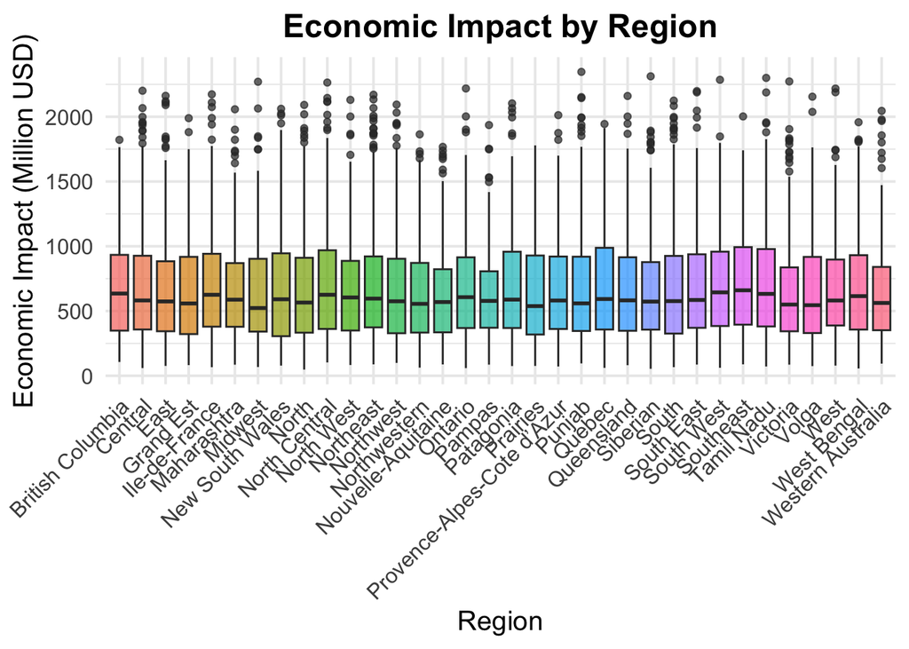

```r
ggplot(climate_data, aes(x = Region, y = Economic_Impact_Million_USD, fill = Region)) +
  geom_boxplot(alpha = 0.7) +
  labs(title = "Economic Impact by Region",
       x = "Region",
       y = "Economic Impact (Million USD)") +
  theme_minimal(base_size = 15) +
  theme(
    plot.title = element_text(hjust = 0.5, size = 18, face = "bold"),
    axis.text.x = element_text(angle = 45, hjust = 1),
    legend.position = "none"
  )
```

This box-plot represents the distribution of economic impact (in millions of USD) for different regions. As you can see, each box represents the middle 50% of data points, and the line inside each box shows us the median economic impact. The whiskers extend to th e minimum and maximum values within the interquartile range, which represents the middle 50% of the data. Data points that go beyond are the outliers and these values are unusually high and this suggests significantly high economic impact. The outliers can point to unusual events that may not represent the typical performance of that region, which can lead to further study on why these values are so different from the rest. ( do it on a map)